# Fisseha Berhane, PhD

## Supervised Machine Learning with R and Python

The data set used for the linear regression models is from [here](https://courses.edx.org/asset-v1:MITx+15.071x_2a+2T2015+type@asset+block/climate_change.csv).

### Linear Regression with R

```r
setwd("C:/Fish/Python/Python_vs_R")
options(jupyter.plot_mimetypes = 'image/png')
options(repr.plot.width = 6)
options(repr.plot.height = 4)
```

```r
clim<-read.csv("climate_change.csv")
```

```r
names(clim)
```

1. "Year"

2. "Month"

3. "MEI"

4. "CO2"

5. "CH4"

6. "N2O"

7. "CFC.11"

8. "CFC.12"

9. "TSI"

10. "Aerosols"

11. "Temp"

```r
dim(clim)
```

1. 308

2. 11

Let's use the data up to 2006 as training data and test for the years after 2006.

```r
training<-subset(clim,clim$Year<=2006)
testing<-subset(clim,clim$Year> 2006)
```

```r
model1<-lm(Temp~MEI+CO2+CH4+N2O+CFC.11+CFC.12+TSI+Aerosols,data=training)
```

```r
summary(model1)
```

```
Call:
lm(formula = Temp ~ MEI + CO2 + CH4 + N2O + CFC.11 + CFC.12 +
    TSI + Aerosols, data = training)

Residuals:
     Min       1Q   Median       3Q      Max
-0.25888 -0.05913 -0.00082  0.05649  0.32433

Coefficients:
              Estimate Std. Error t value Pr(>|t|)
(Intercept) -1.246e+02  1.989e+01  -6.265 1.43e-09 ***
MEI          6.421e-02  6.470e-03   9.923  < 2e-16 ***
CO2          6.457e-03  2.285e-03   2.826  0.00505 **
CH4          1.240e-04  5.158e-04   0.240  0.81015
N2O         -1.653e-02  8.565e-03  -1.930  0.05467 .
CFC.11      -6.631e-03  1.626e-03  -4.078 5.96e-05 ***
CFC.12       3.808e-03  1.014e-03   3.757  0.00021 ***
TSI          9.314e-02  1.475e-02   6.313 1.10e-09 ***
Aerosols    -1.538e+00  2.133e-01  -7.210 5.41e-12 ***
---
Signif. codes:  0 '***' 0.001 '**' 0.01 '*' 0.05 '.' 0.1 ' ' 1

Residual standard error: 0.09171 on 275 degrees of freedom
Multiple R-squared:  0.7509,	Adjusted R-squared:  0.7436
F-statistic: 103.6 on 8 and 275 DF,  p-value: < 2.2e-16
```

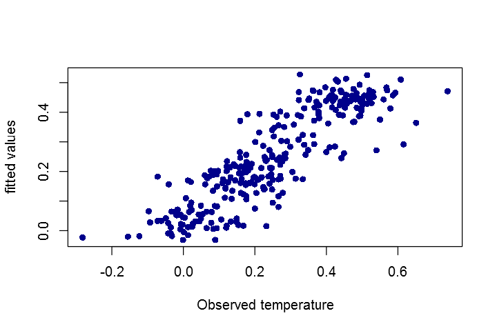

```r
options(repr.plot.width = 6)
options(repr.plot.height = 4)

pred_train<-predict(model1,data=training)

plot(training$Temp,pred_train,col='darkblue',xlab='Observed temperature',ylab='fitted values',pch=16)
```

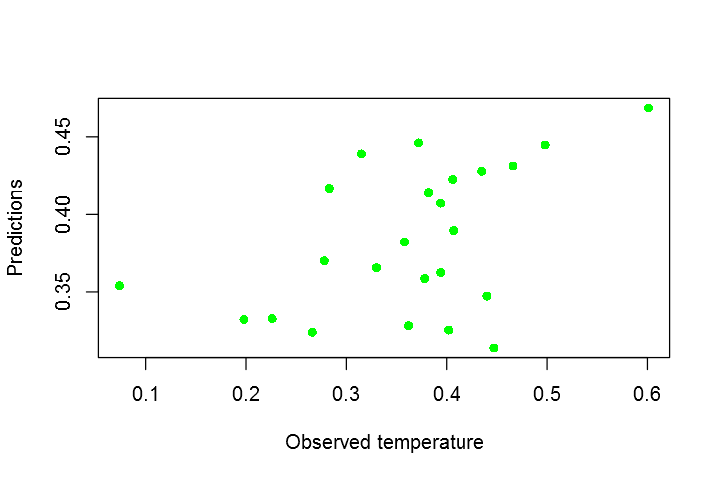

```r
pred_test<-predict(model1, newdata=testing)

plot(testing$Temp,pred_test,col='green',pch=16,xlab='Observed temperature',ylab='Predictions')
```

### Linear Regression with Python

Now, let's see how to build a linear regression model in Python.

```r
import pandas as pd
import numpy as np
import seaborn as sns

import matplotlib.pyplot as plt
%matplotlib inline

from sklearn import metrics
from sklearn.cross_validation import train_test_split
```

#### Read data into a dataframe using pandas.

```r
clim = pd.read_csv(r'https://courses.edx.org/asset-v1:MITx+15.071x_2a+2T2015+type@asset+block/climate_change.csv')
```

Let's look at the covariates.

```r
clim.head(3)
```

|  | Year | Month | MEI | CO2 | CH4 | N2O | CFC-11 | CFC-12 | TSI | Aerosols | Temp |
| --- | --- | --- | --- | --- | --- | --- | --- | --- | --- | --- | --- |
| 0 | 1983 | 5 | 2.556 | 345.96 | 1638.59 | 303.677 | 191.324 | 350.113 | 1366.1024 | 0.0863 | 0.109 |
| 1 | 1983 | 6 | 2.167 | 345.52 | 1633.71 | 303.746 | 192.057 | 351.848 | 1366.1208 | 0.0794 | 0.118 |
| 2 | 1983 | 7 | 1.741 | 344.15 | 1633.22 | 303.795 | 192.818 | 353.725 | 1366.2850 | 0.0731 | 0.137 |

```r
clim.shape
```

```
(308, 11)
```

we can also plot the data. Let's visualize the relationship between the features and the response (temperature) using scatterplots with seaborn.

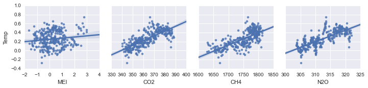

```python
sns.pairplot(clim, x_vars=['MEI','CO2','CH4','N2O'], y_vars='Temp', size=2.5, aspect=1, kind='reg')
```

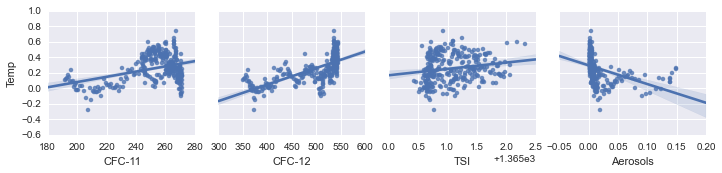

```python
sns.pairplot(clim, x_vars=['CFC-11','CFC-12','TSI','Aerosols'], y_vars='Temp', size=2.5, aspect=1, kind='reg')
```

We can also plot the scatter plots using pandas.

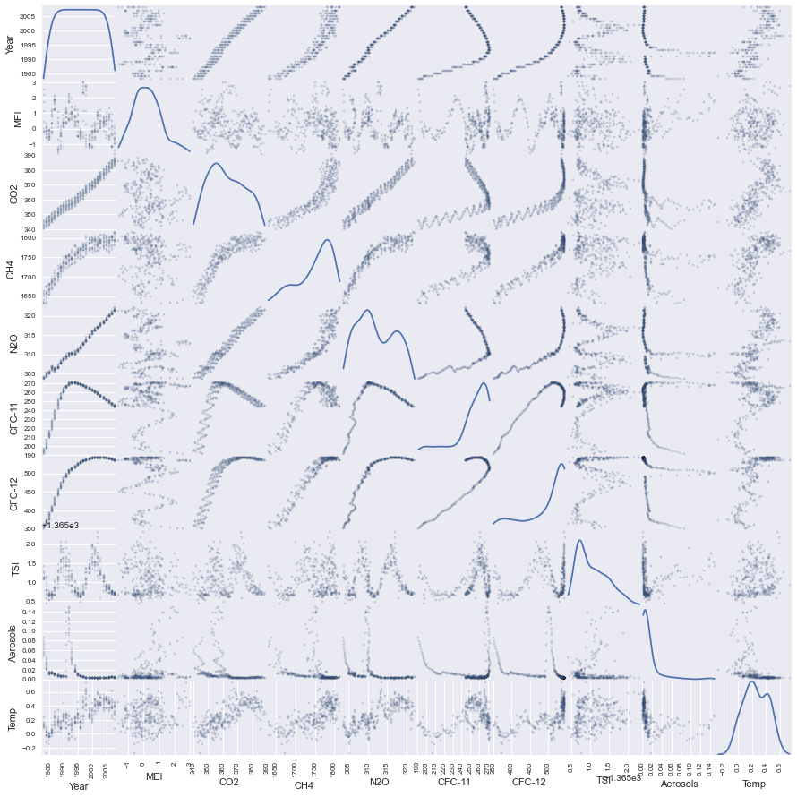

```r
pd.scatter_matrix(clim[['Year','MEI','CO2','CH4','N2O','CFC-11','CFC-12','TSI','Aerosols','Temp']], figsize=(15, 15),alpha=0.2,diagonal='kde')

plt.show()
```

```r
training=clim[clim['Year']<=2006]
testing=clim[clim['Year']>2006]
```

```r
training.shape, testing.shape
```

```
((284, 11), (24, 11))
```

```r
np.unique(training['Year'])
```

```
array([1983, 1984, 1985, 1986, 1987, 1988, 1989, 1990, 1991, 1992, 1993,
       1994, 1995, 1996, 1997, 1998, 1999, 2000, 2001, 2002, 2003, 2004,
       2005, 2006], dtype=int64)
```

The training period covers from 1983 to 2006.

```r
np.unique(testing['Year'])
```

```
array([2007, 2008], dtype=int64)
```

The testing data covers 2007 and 2008.

```r
### SCIKIT-LEARN ###

from sklearn import linear_model

linear = linear_model.LinearRegression()

# create X and y

feature_cols = ['MEI','CO2','CH4','N2O','CFC-11','CFC-12','TSI','Aerosols']
X = training[feature_cols]
y = training.Temp

#  fit
linear.fit(X, y)

print 'R-squared: %0.2f'%linear.score(X,y)
```

```
R-squared: 0.75
```

or we can calculate the R-squared value using the metrics.r2_score method.

```r
y_pred = linear.predict(X)
round(metrics.r2_score(y, y_pred),2)
```

```
0.75
```

The R-squared value is 0.75, the same with what R gives us.

print the coefficients

```r
print('Coefficient: \n', linear.coef_)
print('Intercept: \n', linear.intercept_)
```

```
('Coefficient: \n', array([  6.42053134e-02,   6.45735927e-03,   1.24041896e-04,
        -1.65280033e-02,  -6.63048889e-03,   3.80810324e-03,
         9.31410835e-02,  -1.53761324e+00]))
('Intercept: \n', -124.5942604011142)
```

```r
feature_cols = ['MEI','CO2','CH4','N2O','CFC-11','CFC-12','TSI','Aerosols']
X_test = testing[feature_cols]
predicted= linear.predict(X_test)
obs_pred=pd.DataFrame({"Observation":testing.Temp,"Predicted":predicted})
```

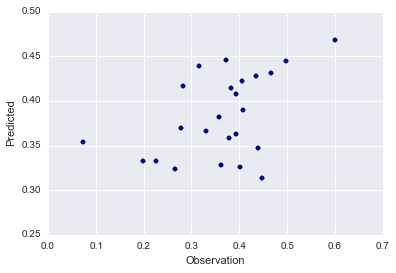

```r
obs_pred.plot(kind='scatter', x='Observation', y='Predicted',color='DarkBlue')
plt.show()
```

or using seaborn:

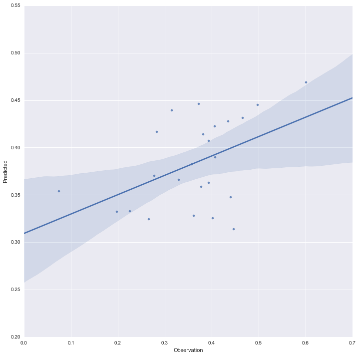

```r
sns.pairplot(obs_pred, x_vars=['Observation'], y_vars='Predicted', size=10, aspect=1, kind='reg')
plt.show()
```

### Predicting loan repayment with Logistic Regression

Let's predict the risk of a borrower being unable to repay a loan. The data set used here is from [LendingClub.com](https://www.lendingclub.com/info/download-data.action).

Our response is the 'not_fully_paid' variable which shows that loan was not paid back in full. The data used here can be downloaded from [here](https://courses.edx.org/asset-v1:MITx+15.071x_2a+2T2015+type@asset+block/loans_imputed.csv).

### Logistic Regression with R

```r
setwd("C:/Fish/Python/Python_vs_R")
```

```r
loans<-read.csv("loans_imputed.csv")
```

Let's explore the dataset.

```r
str(loans)
```

```
'data.frame':	9578 obs. of  14 variables:
 $ credit.policy    : int  1 1 1 1 1 1 1 1 1 1 ...
 $ purpose          : Factor w/ 7 levels "all_other","credit_card",..: 3 2 3 3 2 2 3 1 5 3 ...
 $ int.rate         : num  0.119 0.107 0.136 0.101 0.143 ...
 $ installment      : num  829 228 367 162 103 ...
 $ log.annual.inc   : num  11.4 11.1 10.4 11.4 11.3 ...
 $ dti              : num  19.5 14.3 11.6 8.1 15 ...
 $ fico             : int  737 707 682 712 667 727 667 722 682 707 ...
 $ days.with.cr.line: num  5640 2760 4710 2700 4066 ...
 $ revol.bal        : int  28854 33623 3511 33667 4740 50807 3839 24220 69909 5630 ...
 $ revol.util       : num  52.1 76.7 25.6 73.2 39.5 51 76.8 68.6 51.1 23 ...
 $ inq.last.6mths   : int  0 0 1 1 0 0 0 0 1 1 ...
 $ delinq.2yrs      : int  0 0 0 0 1 0 0 0 0 0 ...
 $ pub.rec          : int  0 0 0 0 0 0 1 0 0 0 ...
 $ not.fully.paid   : int  0 0 0 0 0 0 1 1 0 0 ...
```

```r
set.seed(144)

library(caTools)

split=sample.split(loans$not.fully.paid,SplitRatio = 0.7)

train<-loans[split==TRUE, ]
test<-loans[split==FALSE, ]

mod1<-glm(not.fully.paid~., data=train, family=binomial)
```

Let's see the significant features.

```r
summary(mod1)
```

```
Call:
glm(formula = not.fully.paid ~ ., family = binomial, data = train)

Deviance Residuals:
    Min       1Q   Median       3Q      Max
-2.2049  -0.6205  -0.4951  -0.3606   2.6397

Coefficients:
                            Estimate Std. Error z value Pr(>|z|)
(Intercept)                9.187e+00  1.554e+00   5.910 3.42e-09 ***
credit.policy             -3.368e-01  1.011e-01  -3.332 0.000861 ***
purposecredit_card        -6.141e-01  1.344e-01  -4.568 4.93e-06 ***
purposedebt_consolidation -3.212e-01  9.183e-02  -3.498 0.000469 ***
purposeeducational         1.347e-01  1.753e-01   0.768 0.442201
purposehome_improvement    1.727e-01  1.480e-01   1.167 0.243135
purposemajor_purchase     -4.830e-01  2.009e-01  -2.404 0.016203 *
purposesmall_business      4.120e-01  1.419e-01   2.905 0.003678 **
int.rate                   6.110e-01  2.085e+00   0.293 0.769446
installment                1.275e-03  2.092e-04   6.093 1.11e-09 ***
log.annual.inc            -4.337e-01  7.148e-02  -6.067 1.30e-09 ***
dti                        4.638e-03  5.502e-03   0.843 0.399288
fico                      -9.317e-03  1.710e-03  -5.448 5.08e-08 ***
days.with.cr.line          2.371e-06  1.588e-05   0.149 0.881343
revol.bal                  3.085e-06  1.168e-06   2.641 0.008273 **
revol.util                 1.839e-03  1.535e-03   1.199 0.230722
inq.last.6mths             8.437e-02  1.600e-02   5.275 1.33e-07 ***
delinq.2yrs               -8.320e-02  6.561e-02  -1.268 0.204762
pub.rec                    3.300e-01  1.139e-01   2.898 0.003756 **
---
Signif. codes:  0 '***' 0.001 '**' 0.01 '*' 0.05 '.' 0.1 ' ' 1

(Dispersion parameter for binomial family taken to be 1)

    Null deviance: 5896.6  on 6704  degrees of freedom
Residual deviance: 5485.2  on 6686  degrees of freedom
AIC: 5523.2

Number of Fisher Scoring iterations: 5
```

Now, we can predict using the test data.

```r
predicted.risk=predict(mod1,newdata=test, type="response")
test$predicted.risk=predicted.risk
```

Let's plot the [Receiver operating characteristic](https://en.wikipedia.org/wiki/Receiver_operating_characteristic) (ROC) curve.

```r
# load ROCR package

library(ROCR)
```

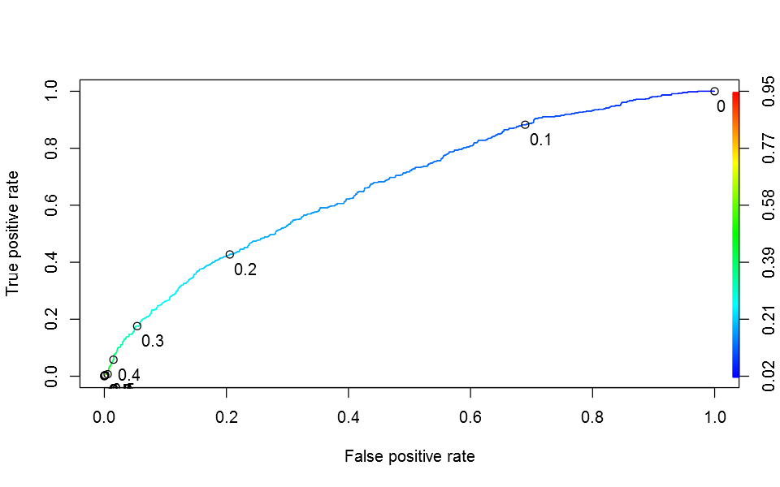

```r
# Prediction function

ROCRpred = prediction(test$predicted.risk,test$not.fully.paid)

# Performance function

ROCRperf = performance(ROCRpred, "tpr", "fpr")

# Plot ROC curve

options(repr.plot.width = 8)
options(repr.plot.height = 5)

plot(ROCRperf, colorize=TRUE, print.cutoffs.at=seq(0,1,by=0.1), text.adj=c(-0.2,1.7))
```

Now, let's calculate the area under the curve (AUC) value. AUC is equal to the probability that a classifier will rank a randomly chosen positive instance higher than a randomly chosen negative one (assuming 'positive' ranks higher than 'negative')

```r
# AUC
round(as.numeric(performance(ROCRpred, "auc")@y.values),2)
```

0.67

We can also calculate [confusion matrix](https://en.wikipedia.org/wiki/Confusion_matrix) and derivates from the confusion matrix.

```r
# The confusion matrix can be computed with the following commands:

test$predicted.risk = predict(mod1, newdata=test, type="response")

table(test$not.fully.paid, test$predicted.risk > 0.5) # using 0.5 as a threshold
```

```
    FALSE TRUE
  0  2400   13
  1   457    3
```

Now, let's calculate accuracy, sensitivity and specificity.

```r
accuracy=round(sum(diag(table(test$not.fully.paid, test$predicted.risk > 0.5)))/sum(table(test$not.fully.paid, test$predicted.risk > 0.5)),2)

sensitivity=round(3/16,2)

specificity=round(2400/(2400+457),2)


cat("\tAccuracy = ",accuracy ,"\n", "\tSensitivity = ",sensitivity, "\n","\tSpecificity = ",specificity ,"\n")
```

[output not shown]

### Logistic Regression with Python

```r
loan = pd.read_csv(r'http://courses.edx.org/asset-v1:MITx+15.071x_2a+2T2015+type@asset+block/loans_imputed.csv')
```

Let's have a look at the dataset.

```r
loan.head(3)
```

|  | credit.policy | purpose | int.rate | installment | log.annual.inc | dti | fico | days.with.cr.line | revol.bal | revol.util | inq.last.6mths | delinq.2yrs | pub.rec | not.fully.paid |
| --- | --- | --- | --- | --- | --- | --- | --- | --- | --- | --- | --- | --- | --- | --- |
| 0 | 1 | debt_consolidation | 0.1189 | 829.10 | 11.350407 | 19.48 | 737 | 5639.958333 | 28854 | 52.1 | 0 | 0 | 0 | 0 |
| 1 | 1 | credit_card | 0.1071 | 228.22 | 11.082143 | 14.29 | 707 | 2760.000000 | 33623 | 76.7 | 0 | 0 | 0 | 0 |
| 2 | 1 | debt_consolidation | 0.1357 | 366.86 | 10.373491 | 11.63 | 682 | 4710.000000 | 3511 | 25.6 | 1 | 0 | 0 | 0 |

```r
loan.shape
```

```
(9578, 14)
```

Let's create a Python list of feature names and use the list to select a subset of the original DataFrame.

```r
# create a Python list of feature names

feature_cols = ['credit.policy', 'int.rate','installment','log.annual.inc','dti','fico','days.with.cr.line','revol.bal','revol.util'
,'inq.last.6mths','delinq.2yrs','pub.rec']

# use the list to select a subset of the original DataFrame

X = loan[feature_cols]

# print the first 5 rows of the features.
X.head()
```

|  | credit.policy | int.rate | installment | log.annual.inc | dti | fico | days.with.cr.line | revol.bal | revol.util | inq.last.6mths | delinq.2yrs | pub.rec |
| --- | --- | --- | --- | --- | --- | --- | --- | --- | --- | --- | --- | --- |
| 0 | 1 | 0.1189 | 829.10 | 11.350407 | 19.48 | 737 | 5639.958333 | 28854 | 52.1 | 0 | 0 | 0 |
| 1 | 1 | 0.1071 | 228.22 | 11.082143 | 14.29 | 707 | 2760.000000 | 33623 | 76.7 | 0 | 0 | 0 |
| 2 | 1 | 0.1357 | 366.86 | 10.373491 | 11.63 | 682 | 4710.000000 | 3511 | 25.6 | 1 | 0 | 0 |
| 3 | 1 | 0.1008 | 162.34 | 11.350407 | 8.10 | 712 | 2699.958333 | 33667 | 73.2 | 1 | 0 | 0 |
| 4 | 1 | 0.1426 | 102.92 | 11.299732 | 14.97 | 667 | 4066.000000 | 4740 | 39.5 | 0 | 1 | 0 |

Then, let's prepare the dependent variable (response).

```r
y = loan['not.fully.paid']


# print the first 5 values of the predictand

y.head()
```

```
0    0
1    0
2    0
3    0
4    0
Name: not.fully.paid, dtype: int64
```

```r
#Import Library
from sklearn.linear_model import LogisticRegression

# Create logistic regression object
model = LogisticRegression()
```

Train the model using the training sets and check score

#### Splitting X and y into training and testing sets

```r
from sklearn.cross_validation import train_test_split
X_train, X_test, y_train, y_test = train_test_split(X, y, random_state=144,test_size=0.3)

# default split is 75% for training and 25% for testing
```

Check that the training data is 70% of the original data and the rest 30% is allocated for testing.

```r
print X_train.shape
print y_train.shape
print X_test.shape
print y_test.shape
```

```
(6704, 12)
(6704L,)
(2874, 12)
(2874L,)
```

```r
# Create logistic regression object
model = LogisticRegression()

# Train the model using the training sets and check score

model.fit(X_train, y_train)
print 'The accuracy of this model is %0.2f' %round(model.score(X_train, y_train),2)
```

```
The accuracy of this model is 0.84
```

The accury is similar using Python and R.

```r
# Equation coefficient and Intercept

print('Coefficient: \n', model.coef_)
print('Intercept: \n', model.intercept_)

#Predict Output
predicted= model.predict(X_test)
```

```
('Coefficient: \n', array([[ -2.92864792e-02,   1.91021226e-03,   8.45693935e-04,
          2.47300223e-03,   3.05574553e-03,  -3.29998968e-03,
         -4.21654188e-05,   1.92812967e-06,   5.57896478e-03,
          1.36024983e-01,   2.14731566e-03,   7.73942901e-03]]))
('Intercept: \n', array([ 0.00289314]))
```

## Decison trees with R

Let's predict the risk of a borrower being unable to repay a loan. The data set used here is from [LendingClub.com](https://www.lendingclub.com/info/download-data.action).

Our response is the 'not_fully_paid' variable which shows that loan was not paid back in full. The data used here can be downloaded from [here](https://courses.edx.org/asset-v1:MITx+15.071x_2a+2T2015+type@asset+block/loans_imputed.csv).

```r
setwd("C:/Fish/Python/Python_vs_R")
```

```r
library(caTools)

loans<-read.csv("loans_imputed.csv")

set.seed(144)

library(caTools)

split=sample.split(loans$not.fully.paid,SplitRatio = 0.7)

train<-loans[split==TRUE, ]
test<-loans[split==FALSE, ]
```

```r
library(rpart)

library(rpart.plot)
```

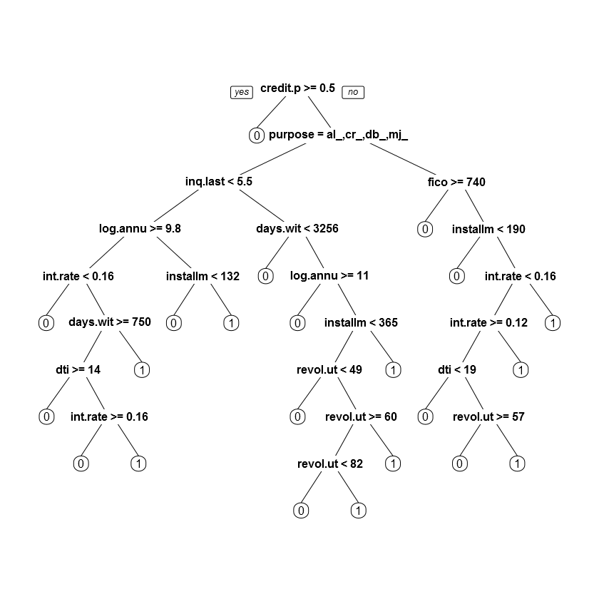

```r
CARTmodel = rpart(not.fully.paid~., data=train, method="class",cp=0.002)

prp(CARTmodel)
```

```r
prediction<-predict(CARTmodel, type="class",newdata=test)

table<-table(prediction,test$not.fully.paid)
accuracy<-sum(diag(table))/(sum(table))
cat("The accuracy is ",round(accuracy,2))
```

```
The accuracy is  0.84
```

The accuracy is similar to what we found using logistic regression using R and Python.

## Decison trees with Python

```r
loan = pd.read_csv(r'http://courses.edx.org/asset-v1:MITx+15.071x_2a+2T2015+type@asset+block/loans_imputed.csv')
```

```r
# create a Python list of feature names

feature_cols = ['credit.policy', 'int.rate','installment','log.annual.inc','dti','fico','days.with.cr.line','revol.bal','revol.util'
,'inq.last.6mths','delinq.2yrs','pub.rec']

# use the list to select a subset of the original DataFrame

X = loan[feature_cols]

# print the first 5 rows
X.head()
```

|  | credit.policy | int.rate | installment | log.annual.inc | dti | fico | days.with.cr.line | revol.bal | revol.util | inq.last.6mths | delinq.2yrs | pub.rec |
| --- | --- | --- | --- | --- | --- | --- | --- | --- | --- | --- | --- | --- |
| 0 | 1 | 0.1189 | 829.10 | 11.350407 | 19.48 | 737 | 5639.958333 | 28854 | 52.1 | 0 | 0 | 0 |
| 1 | 1 | 0.1071 | 228.22 | 11.082143 | 14.29 | 707 | 2760.000000 | 33623 | 76.7 | 0 | 0 | 0 |
| 2 | 1 | 0.1357 | 366.86 | 10.373491 | 11.63 | 682 | 4710.000000 | 3511 | 25.6 | 1 | 0 | 0 |
| 3 | 1 | 0.1008 | 162.34 | 11.350407 | 8.10 | 712 | 2699.958333 | 33667 | 73.2 | 1 | 0 | 0 |
| 4 | 1 | 0.1426 | 102.92 | 11.299732 | 14.97 | 667 | 4066.000000 | 4740 | 39.5 | 0 | 1 | 0 |

```r
# select a Series from the DataFrame
y = loan['not.fully.paid']


# print the first 5 values

y.head()
```

```
0    0
1    0
2    0
3    0
4    0
Name: not.fully.paid, dtype: int64
```

```r
from sklearn.cross_validation import train_test_split
X_train, X_test, y_train, y_test = train_test_split(X, y, random_state=144,test_size=0.3)
```

```r
from sklearn import tree

# Create tree object
model = tree.DecisionTreeClassifier(criterion='gini') # for classification, here you can change the algorithm as gini or entropy (information gain) by default it is gini

# model = tree.DecisionTreeRegressor() for regression
# Train the model using the training sets and check score

model.fit(X_train, y_train)
```

```
DecisionTreeClassifier(class_weight=None, criterion='gini', max_depth=None,
            max_features=None, max_leaf_nodes=None, min_samples_leaf=1,
            min_samples_split=2, min_weight_fraction_leaf=0.0,
            random_state=None, splitter='best')
```

```r
from sklearn import tree
from sklearn.metrics import accuracy_score

clf = tree.DecisionTreeClassifier(min_samples_split=60) # default value of min_samples_split is 2


print round(accuracy_score(clf.fit(X_train,y_train).predict(X_test),y_test),2)
```

```
0.82
```

### Support Vector Machine (SVM) with R

Again, let's predict the risk of a borrower being unable to repay a loan. The data set used here is from [LendingClub.com](https://www.lendingclub.com/info/download-data.action).

Our response is the 'not_fully_paid' variable which shows that loan was not paid back in full. The data used here can be downloaded from [here](https://courses.edx.org/asset-v1:MITx+15.071x_2a+2T2015+type@asset+block/loans_imputed.csv).

```r
setwd("C:/Fish/Python/Python_vs_R")
```

```r
library(caTools)

loans<-read.csv("loans_imputed.csv")

set.seed(144)

library(caTools)

split=sample.split(loans$not.fully.paid,SplitRatio = 0.7)

train<-loans[split==TRUE, ]
test<-loans[split==FALSE, ]
```

```r
library(e1071)
```

```r
fit = svm(not.fully.paid~., data=train)
```

```r
summary(fit)
```

```
Call:
svm(formula = not.fully.paid ~ ., data = train)


Parameters:
   SVM-Type:  eps-regression
 SVM-Kernel:  radial
       cost:  1
      gamma:  0.05263158
    epsilon:  0.1


Number of Support Vectors:  2867
```

Now, let's predict using the test data

```r
predicted= predict(fit,test)
```

We can calculate the confusion matrix

```r
table(test$not.fully.paid,  predicted>0.5)
```

```
    FALSE TRUE
  0  2412    1
  1   459    1
```

```r
cat('Accuracy:=',sum(diag(table(test$not.fully.paid,  predicted>0.5)))/sum(table(test$not.fully.paid,  predicted>0.5)))
```

```
Accuracy:= 0.8398886
```

### Support Vector Machine (SVM) with Python

```r
loan = pd.read_csv(r'http://courses.edx.org/asset-v1:MITx+15.071x_2a+2T2015+type@asset+block/loans_imputed.csv')

# create a Python list of feature names

feature_cols = ['credit.policy', 'int.rate','installment','log.annual.inc','dti','fico','days.with.cr.line','revol.bal','revol.util'
,'inq.last.6mths','delinq.2yrs','pub.rec']


X = loan[feature_cols]

y = loan['not.fully.paid']
```

```r
from sklearn.cross_validation import train_test_split
X_train, X_test, y_train, y_test = train_test_split(X, y, random_state=144,test_size=0.3)
```

```r
#Import Library

from sklearn import svm

model = svm.SVC(kernel='rbf',C=10000.0)  # check with different kernels and C

model.fit(X, y)

model.score(X, y)
#Predict Output
predicted= model.predict(X_test)
```

Calculate accuracy.

```r
from sklearn.metrics import accuracy_score


print 'Accuracy is ', round(accuracy_score(model.fit(X_train,y_train).predict(X_test),y_test),2)
```

```
Accuracy is  0.85
```

### Random Forest with R

```r
setwd("C:/Fish/Python/Python_vs_R")
```

```r
library(caTools)

loans<-read.csv("loans_imputed.csv")

set.seed(144)

library(caTools)

split=sample.split(loans$not.fully.paid,SplitRatio = 0.7)

train<-loans[split==TRUE, ]
test<-loans[split==FALSE, ]
```

```r
library(randomForest)
```

```r
fit = randomForest(as.factor(not.fully.paid)~., data=train)
```

```r
fit
```

```
Call:
 randomForest(formula = as.factor(not.fully.paid) ~ ., data = train)
               Type of random forest: classification
                     Number of trees: 500
No. of variables tried at each split: 3

        OOB estimate of  error rate: 16.09%
Confusion matrix:
     0  1 class.error
0 5606 26 0.004616477
1 1053 20 0.981360671
```

Let's see variable importance.

```r
importance (fit)
```

|  | MeanDecreaseGini |
| --- | --- |
| credit.policy | 28.60945 |
| purpose | 90.82407 |
| int.rate | 187.8175 |
| installment | 203.7339 |
| log.annual.inc | 198.4494 |
| dti | 200.5874 |
| fico | 138.7061 |
| days.with.cr.line | 204.8603 |
| revol.bal | 197.2738 |
| revol.util | 200.1005 |
| inq.last.6mths | 98.60741 |
| delinq.2yrs | 26.74009 |
| pub.rec | 17.31238 |

We can plot variable importance from the Random Forest model.

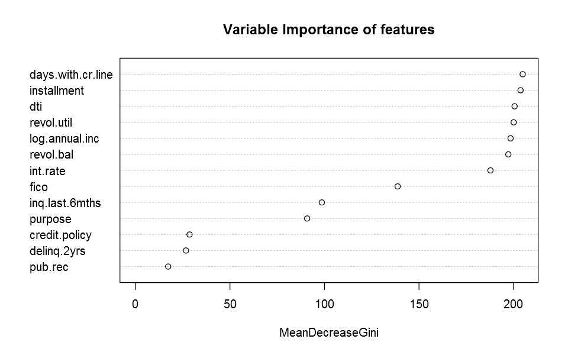

```r
options(repr.plot.width = 8)
options(repr.plot.height = 5)

varImpPlot(fit,main ="Variable Importance of features")
```

```r
prediction=predict(fit, test)
```

```r
accuracy = sum(prediction==test$not.fully.paid)/length(test$not.fully.paid)
round(accuracy,2)
```

0.84

### Random Forest with Python

```r
loan = pd.read_csv(r'http://courses.edx.org/asset-v1:MITx+15.071x_2a+2T2015+type@asset+block/loans_imputed.csv')

# create a Python list of feature names

feature_cols = ['credit.policy', 'int.rate','installment','log.annual.inc','dti','fico','days.with.cr.line','revol.bal','revol.util'
,'inq.last.6mths','delinq.2yrs','pub.rec']


X = loan[feature_cols]

y = loan['not.fully.paid']
```

```r
from sklearn.cross_validation import train_test_split
X_train, X_test, y_train, y_test = train_test_split(X, y, random_state=144,test_size=0.3)
```

```r
#Import Library

from sklearn.ensemble import RandomForestClassifier


model = RandomForestClassifier()

model.fit(X, y)

model.score(X, y)
#Predict Output
predicted= model.predict(X_test)
```

```r
from sklearn.metrics import accuracy_score

print 'Accuracy is ', round(accuracy_score(model.fit(X_train,y_train).predict(X_test),y_test),2)
```

```
Accuracy is  0.84
```

Let's standardize the data and see the how the accuracy changes.

```r
from sklearn import preprocessing

std_scale = preprocessing.StandardScaler().fit(X_train)
X_train = std_scale.transform(X_train)
X_test = std_scale.transform(X_test)
```

```r
model = RandomForestClassifier()

model.fit(X, y)

model.score(X, y)
#Predict Output
predicted= model.predict(X_test)
```

```r
from sklearn.metrics import accuracy_score

print 'Accuracy is ', round(accuracy_score(model.fit(X_train,y_train).predict(X_test),y_test),2)
```

```
Accuracy is  0.84
```

Conclusion